# yelp_0213

## Sentiment Anlysis of Yelp Reviews

In this project, I'll explore restaurant review data available through the [Yelp Dataset Challenge](https://www.yelp.com/dataset). It includes Yelp data for user reviews and business information for 10 metropolitan areas, and this project will choose Cleveland, Pittsburgh, and Charlotte as the examples to explore Yelp's review.

This project is broken into two parts:

#### Part 1: testing how well sentiment analysis works in Yelp review.

Because Yelp reviews include the number of stars given by the user, the Yelp dataset provides a unique opportunity to test how well the sentiment analysis works by comparing the number of stars to the polarity of reviews.

#### Part 2: analyzing correlations between restaurant reviews and census data

I'll explore geographic trends in the restaurant reviews, comparing our sentiment analysis results with user stars geographically. I'll also overlay review stars on maps of household income (using census data).

#### Background

- [Does sentiment analysis work?](http://varianceexplained.org/r/yelp-sentiment/)
- [The Geography of Taste: Using Yelp to Study Urban Culture](https://www.mdpi.com/2220-9964/7/9/376/pdf/1)

```python
# http://zhenzhaoxu.com/works/python-yelp/
# https://gillianzhaoxz.github.io/web/assets/doc/yelp_sentiment.html
```

## 1. Does Sentiment Analysis Work?

In this part, we'll load the data, perform a sentiment analysis, and explore the results.

### 1.1 Load review data

```python
import pandas as pd
import seaborn as sns
from matplotlib import pyplot as plt
import geopandas as gpd
```

```python
charlotte_rw = pd.read_json('data/reviews_charlotte.json.gz',orient='records',lines=True)
cleveland_rw = pd.read_json('data/reviews_cleveland.json.gz',orient='records',lines=True)
pittsburgh_rw = pd.read_json('data/reviews_pittsburgh.json.gz',orient='records',lines=True)
```

### 1.2 Format the review text

The first step is to split the review text into its individual words and make all of the words lower-cased.

Add a new column, called 'formatted_text', which each entry is a list of the lower-cased words in a review.

```python
pittsburgh_rw['formatted_text'] = pittsburgh_rw['text'].str.lower()
pittsburgh_rw['formatted_text'] = pittsburgh_rw['formatted_text'].str.split()
pittsburgh_rw.head()
```

|  | business_id | review_id | stars | text | formatted_text |
| --- | --- | --- | --- | --- | --- |
| 0 | eU_713ec6fTGNO4BegRaww | fdiNeiN_hoCxCMy2wTRW9g | 4 | I'll be the first to admit that I was not exci... | [i'll, be, the, first, to, admit, that, i, was... |
| 1 | FxLfqxdYPA6Z85PFKaqLrg | Z7wgXp98wYB57QdRY3HQ3w | 4 | Wow. So surprised at the one and two star revi... | [wow., so, surprised, at, the, one, and, two, ... |
| 2 | 9nTF596jDvBBia2EXXiOOg | 1daGBpea0sleayFeeXuoYw | 1 | if i can give this place no stars i would, i o... | [if, i, can, give, this, place, no, stars, i, ... |
| 3 | sMzNLdhJZGzYirIWt-fMAg | RLbWoIri29BcQ8yjzsvQLQ | 5 | This place epitomizes the rumored transformati... | [this, place, epitomizes, the, rumored, transf... |
| 4 | hcFSc0OHgZJybnjQBrL_8Q | vAckaF8n0KKJeqHOnb1ayw | 4 | Here's why I don't write reviews for Chinese r... | [here's, why, i, don't, write, reviews, for, c... |

### 1.3 Review stop words

Use the `nltk` library to remove any stop words from the list of words in each review.

Overwrite the 'formatted_text' column to contain a list of lower-cased words in each review, with no stop words.

```python
# import and download the stop words
import nltk
nltk.download('stopwords');

# get stop words as list
#stop_words = list(set(nltk.corpus.stopwords.words('english')))
stop_words = nltk.corpus.stopwords.words('english')
```

```python
# remove the stop word from the formatted text
pittsburgh_rw['formatted_text2'] = [[word for word in sentence if word not in list(stop_words)]
              for sentence in list(pittsburgh_rw['formatted_text'])]


# double check whether remove the stop words from the text
len_origin = [len(i) for i in pittsburgh_rw['formatted_text'][0:10]]
len_no_stop = [len(i) for i in pittsburgh_rw['formatted_text2'][0:10]]

display(len_origin)
display(len_no_stop)
```

```
[295, 208, 123, 45, 179, 10, 44, 74, 22, 324]
```

```
[151, 108, 61, 24, 90, 8, 29, 37, 16, 171]
```

### 1.4 Calculate polarity and subjectivity

Using the formatted text column, create a list of `textblob.TextBlob()` objects and then extract the `subjectivity` and `polarity`.

Add two new columns to the review DataFrame: `polarity` and `subjectivity`.

```python
import textblob

# create textblob for each formatted_text2
blobs = []
for t in pittsburgh_rw['formatted_text2']:
    # for the column, join the list in to one string, and then calculate textblob
    blobs.append(textblob.TextBlob(' '.join(t)))

'''
similar to
blobs = [textblob.TextBlob(' '.join(t)) for t in pittsburgh_rw['formatted_text'][1:10]]

'''

# get the polarity and subjectivity number, and add as two columns
pittsburgh_rw['polarity'] = [i.sentiment.polarity for i in blobs]
pittsburgh_rw['subjectivity'] = [i.sentiment.subjectivity for i in blobs]
```

### 1.5 Comparing the sentiment analysis to number of stars

Use `seaborn` to make two box plots, one showing the polarity vs **number of user stars** and one showing the subjectivity vs the number of user stars.

```python
pittsburgh_rw['Polarity']  = round(pittsburgh_rw['polarity'] , 3)
pittsburgh_rw['Subjectivity']  = round(pittsburgh_rw['subjectivity'] , 3)
```

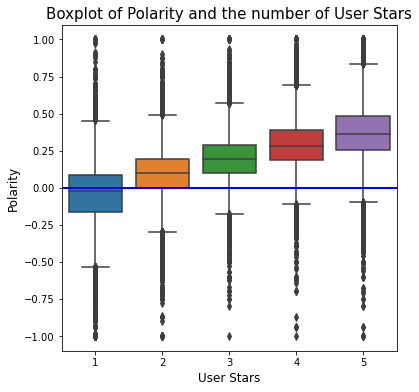

```python
fig, ax = plt.subplots(figsize=(6, 6))

sns.boxplot(x='stars', y='Polarity', data=pittsburgh_rw, ax=ax)
ax.axhline(y=0, c='blue', lw=2) # neutral
ax.tick_params(labelsize=10)
plt.xlabel('User Stars', fontsize=12)
plt.ylabel('Polarity', fontsize=12)
ax.set_title("Boxplot of Polarity and the number of User Stars", size =15)
```

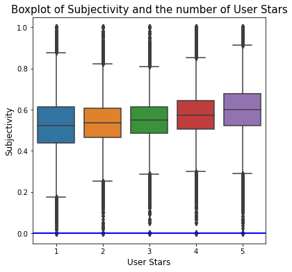

```python
fig, ax = plt.subplots(figsize=(6, 6))

sns.boxplot(x='stars',y='Subjectivity', data=pittsburgh_rw, ax=ax)
ax.axhline(y=0, c='blue', lw=2) # neutral
ax.tick_params(labelsize=10)
plt.xlabel('User Stars', fontsize=12)
plt.ylabel('Subjectivity', fontsize=12)
ax.set_title("Boxplot of Subjectivity and the number of User Stars", size =15)
```

The diagrams generally show the sentiment analysis is quite effctive in this case: polarity and subjectivity scores are positivily correlated with users' rating. The variation between different user stars groups concerning the level of polirization is larger than that of subjectivity. While there are a lot of information that boxplots don't tell, for example does the restaurants' location or type impact the reviews?

### 1.6 The importance of individual words

In this part, we'll explore the importance and frequency of individual words in Yelp reviews.

We will identify the most common reviews and then plot the average polarity vs the user stars for the reviews where those words occur.

#### 1.6.1 Select a random sample of the review data

Select 1,000 random rows from the DataFrame holding the review data. Use the `.sample()` function to perform the selection.

```python
sample = pittsburgh_rw.sample(1000)
```

#### 1.6.2 Re-format the data

Pass the subset of review data from the previous part to the `reshape_data()` function defined below. Explore the result of this function, and in one or two sentences, explain the operation performed by `reshape_data()`.

```python
def reshape_data(review_subset):
    """
    Reshape the input dataframe of review data.
    """
    from pandas import Series, merge

    X = (review_subset['formatted_text2']
         .apply(Series)
         .stack()
         .reset_index(level=1, drop=True)
         .to_frame('word'))


    R = review_subset[['polarity', 'stars', 'review_id']]

    return merge(R, X, left_index=True, right_index=True).reset_index(drop=True)

shape_sample = reshape_data(sample)
```

#### 1.6.3 Calculate the average number of stars and polarity for each word

Using the result from 1.6.2, group by the "word" column, and calculate the following three quantities:

1. the size of each group
2. the average number of user stars for each word
3. the average polarity for each word

Combine these three results into a single DataFrame object.

```python
# groupby
size = shape_sample.groupby('word', as_index =False).size()
polarity_mean = shape_sample.groupby('word', as_index =False)['polarity'].mean()
stars_mean = shape_sample.groupby('word', as_index =False)['stars'].mean()

# merge three colume together
sample_merge = pd.merge(size,polarity_mean)
sample_merge = pd.merge(sample_merge,stars_mean)
sample_merge.set_axis(['word','size','mean_polarity','mean_stars'], axis =1, inplace =True)
```

#### 1.6.4 Select words the occur at least 50 times in reviews

Trim your DataFrame from the last section to only include words that occurred at least 50 times. Remember, when you grouped by the 'word' column, the `size()` function told you how many times each word occurred.

```python
# select the words that occur >= 50
sample_merge = sample_merge[sample_merge['size']>=50]
```

#### 1.6.5 Plot the average polarity vs user stars

Use `matplotlib` to make a scatter plot of the **average user stars** vs **average polarity** for the words in the data frame from the last section. This will involve two steps:

Loop over each row of the data frame from the last section and for each row:

1. Use `plt.scatter(x, y)` to plot a scatter plot, where x is polarity and y is stars.
2. Use `plt.text(x, y, word)` to add the corresponding word to each scatter marker.

Using the data frame from section 1.4, add vertical and horizontal lines to your chart that shows the average number of user stars and the average polarity across all reviews in the data set.

Make sure the figure is big enough so that you can make out some of the words, especially at low and high polarity values. You should be able to see a strong trend between polarity and user stars, and some of the most common words occurring in these reviews.

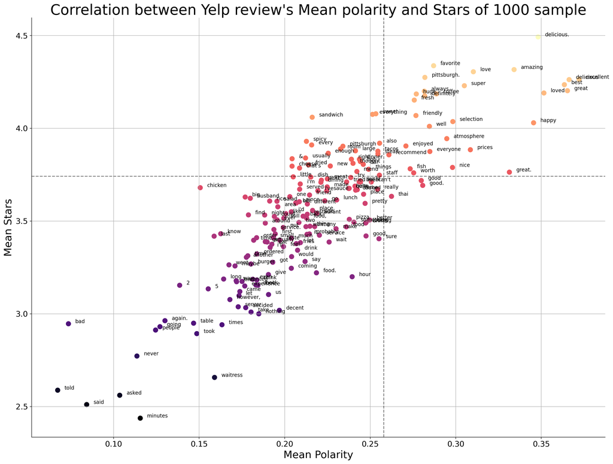

```python
fig, ax = plt.subplots(figsize=(20, 15),dpi=200
                      )
plt.scatter(x=sample_merge['mean_polarity'],
            y=sample_merge['mean_stars'],
           c=sample_merge['mean_stars'],
           cmap='magma',
           s=80)


for i in range(0,len(sample_merge)):
    plt.text(list(sample_merge['mean_polarity'])[i]+0.004,
             list(sample_merge['mean_stars'])[i]+0.004,
            list(sample_merge['word'])[i],
            size=10)


# add horizontal line, mean of stars
ax.axhline(y=pittsburgh_rw['stars'].mean(), c='black',
           lw=1.5, linestyle='--',alpha=0.5)
# add vertical line, mean of polarity
ax.axvline(x=pittsburgh_rw['polarity'].mean(), c='black',
           lw=1.5,linestyle='--',alpha=0.5) #

# set lable
ax.tick_params(labelsize=15)
plt.xlabel('Mean Polarity', fontsize=20)
plt.ylabel('Mean Stars', fontsize=20)

# set title
ax.set_title("Correlation between Yelp review's Mean polarity and Stars of 1000 sample", size =28)

# Remove the top and right axes lines
plt.grid(True)
ax.spines["top"].set_visible(False)
ax.spines["right"].set_visible(False)
```

## 2. Correlating restaurant data and household income

In this part, we'll use the census API to download household income data and overlay restaurant locations.

### 2.1 Query the Census API

Use the `cenpy` package to download **median household income in the past 12 months** by census tract from the 2018 ACS 5-year data set for your county of interest.

I will initialize an API connection and use the `.varslike()` function to search for the proper keywords

The FIPS codes for the various state/counties are:

- Pittsburgh
  - PA code: '42'
  - County code: '003' (Allegheny County)
- Cleveland
  - OH code: '39'
  - County code: '035' (Cuyahoga County)
- Charlotte
  - NC code: '37'
  - County code: '119' (Mecklenburg County)

```python
import cenpy
pd.options.display.max_columns = 999
pd.options.display.max_rows = 999
pd.options.display.max_colwidth = 200
# get 2018 ACS 5-year data
acs = cenpy.remote.APIConnection("ACSDT5Y2018")

# Set the map service for pulling geometries
acs.set_mapservice("tigerWMS_ACS2018")
```

```
Connection to American Community Survey: 5-Year Estimates: Detailed Tables 5-Year(ID: https://api.census.gov/data/id/ACSDT5Y2018)
With MapServer: Census ACS 2018 WMS
```

```python
# get variable that related to median household income in the past 12 months
variable = ("median household income in the past 12 months")
variable = variable.upper()

va = acs.varslike(variable, by='concept').sort_index()

# print all variable
#for i in va['label']:
#    print(i)

# extract variables
variables = [
    "NAME",
    'B19049_001E', # Estimate!!Median household income in the past 12 months (in 2018 inflation-adjusted dollars) --!!Total
    'B19013A_001E',# Estimate!!Median household income in the past 12 months (in 2018 inflation-adjusted dollars)
]
```

```python
# check the available geographies
acs.geographies['fips']
```

### 2.2 Download census tracts from the Census and merge the data from Part 2.1

- Use the `cenpy` to set the correct map service and download census tracts for the desired geography
- Merge the downloaded census tracts with the household income DataFrame, making sure to specify the proper columns to perform the merge on.

```python
# get the FIP codes for county
counties = cenpy.explorer.fips_table("COUNTY")
counties[counties[3].str.contains("Allegheny|Cuyahoga|Mecklenburg") &
         counties[0].str.contains("NC|OH|PA") ]
```

|  | 0 | 1 | 2 | 3 | 4 |
| --- | --- | --- | --- | --- | --- |
| 1949 | NC | 37 | 119 | Mecklenburg County | H1 |
| 2060 | OH | 39 | 35 | Cuyahoga County | H1 |
| 2245 | PA | 42 | 3 | Allegheny County | H1 |

```python
# state code, county code
code = [['42','003'],['39','035'],['37','119']]

# extract the census data of three county from dataset
three_df = pd.DataFrame([])
for a in code:
    data = acs.query(
        # the list of variables desired from the dataset
        cols=variables,
        # represent the smallest geo unit
        geo_unit="block group:*",
        geo_filter={"state": a[0],
                    "county": a[1],
                    "tract": "*"})
    three_df = three_df.append(data)

three_sf = pd.DataFrame([])
# extract the geo info of three county
for a in code:
    # Use SQL to return geometries only three county's info
    where_clause = f"STATE = {a[0]} AND COUNTY = {a[1]}"
    # Query for block groups
    # layers[10] = census block groups
    three_block_groups = acs.mapservice.layers[10].query(where=where_clause)
    # append three county together
    three_sf = three_sf.append(three_block_groups)

# merge sf and df
three_all = three_sf.merge(
    three_df,
    left_on=["STATE", "COUNTY", "TRACT", "BLKGRP"],
    right_on=["state", "county", "tract", "block group"],
)
```

### 2.3 Plot a choropleth map of the household income

Use the built-in `geopandas` `plot()` function.

Be sure to convert to a reasonable CRS first!

```python
# Check the CRS
three_all.crs
```

```
<Projected CRS: EPSG:3857>
Name: WGS 84 / Pseudo-Mercator
Axis Info [cartesian]:
- E[east]: Easting (metre)
- N[north]: Northing (metre)
Area of Use:
- name: World between 85.06°S and 85.06°N.
- bounds: (-180.0, -85.06, 180.0, 85.06)
Coordinate Operation:
- name: Popular Visualisation Pseudo-Mercator
- method: Popular Visualisation Pseudo Mercator
Datum: World Geodetic System 1984
- Ellipsoid: WGS 84
- Prime Meridian: Greenwich
```

```python
# tranform string to int
three_all['B19049_001E'] = three_all['B19049_001E'].astype(int)

# select area with valid info
three_all_2 = three_all.loc[three_all['B19049_001E']!=-666666666]

# split three cities
pittsburgh = three_all_2.loc[three_all_2['NAME_y'].str.contains("Allegheny")]
cleveland = three_all_2.loc[three_all_2['NAME_y'].str.contains("Cuyahoga")]
charlotte = three_all_2.loc[three_all_2['NAME_y'].str.contains("Mecklenburg")]

# Needed to line up the colorbar properly
from mpl_toolkits.axes_grid1 import make_axes_locatable

# put three df into list for loop
three_list = [charlotte,cleveland,pittsburgh]

# set three diagrams' title
title_list = ['2018 Median Household Income in Charlotte',
              '2018 Median Household Income in Cleveland',
              '2018 Median Household Income in Pittsburgh'
             ]
```

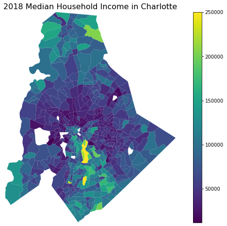

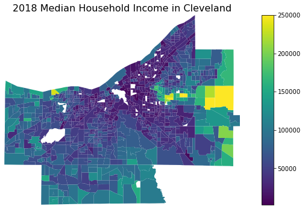

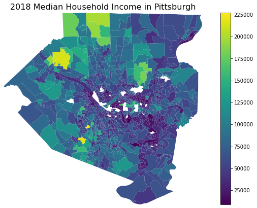

```python
# Plot the choropleth
for i in range(0,len(three_list)) :
    fig, ax= plt.subplots(figsize=(8,8))
    # create a lined up colorbar axes
    divider = make_axes_locatable(ax)
    cax = divider.append_axes("right", size="5%", pad=0.5)

    three_list[i].plot(ax=ax,
    cax = cax,
    column='B19049_001E', legend=True)

    # Get the limits of the GeoDataFrame
    xmin, ymin, xmax, ymax = three_list[i].total_bounds

    # Set the xlims and ylims
    ax.set_xlim(xmin, xmax)
    ax.set_ylim(ymin, ymax)

    # Format
    ax.set_title(title_list[i], fontsize=16)
    ax.set_axis_off()
```

### 2.4 Load the restaurants data

Use the `latitude` and `longitude` columns to create a GeoDataFrame after loading the JSON data.

```python
resta_char = pd.read_json('data/restaurants_charlotte.json.gz',orient='records',lines=True)
resta_cleve = pd.read_json('data/restaurants_cleveland.json.gz',orient='records',lines=True)
resta_pitts= pd.read_json('data/restaurants_pittsburgh.json.gz',orient='records',lines=True)

resta_pitts.head()
```

|  | business_id | latitude | longitude | name | review_count | stars |
| --- | --- | --- | --- | --- | --- | --- |
| 0 | 1RHY4K3BD22FK7Cfftn8Mg | 40.496177 | -80.246011 | Marathon Diner | 35 | 4.0 |
| 1 | dQj5DLZjeDK3KFysh1SYOQ | 40.465694 | -79.949324 | Apteka | 242 | 4.5 |
| 2 | v-scZMU6jhnmV955RSzGJw | 40.441062 | -80.002126 | No. 1 Sushi Sushi | 106 | 4.5 |
| 3 | t-6tdxRaz7s9a0sf94Tguw | 40.462345 | -79.924165 | Impressionz | 29 | 4.5 |
| 4 | 5WMIvoMx3l1vn1uJ3HZB6Q | 40.442863 | -79.996412 | Subway | 3 | 3.0 |

```python
three_list_resta = [resta_char, resta_cleve,resta_pitts]

# change three restaurant to sf
three_list_resta_sf = []
for i in three_list_resta:
    i = i.dropna(subset=['latitude', 'longitude'])

    # set cordinates
    i['Coordinates'] = gpd.points_from_xy(i['longitude'], i['latitude'])

    # transform it to geo dataframe
    i = gpd.GeoDataFrame(i,
                       geometry="Coordinates",
                       crs="EPSG:4326")
    # change crs to 3857
    i = i.to_crs(epsg=3857)
    three_list_resta_sf.append(i)

three_list_resta_sf[0].crs
```

```
<Projected CRS: EPSG:3857>
Name: WGS 84 / Pseudo-Mercator
Axis Info [cartesian]:
- X[east]: Easting (metre)
- Y[north]: Northing (metre)
Area of Use:
- name: World between 85.06°S and 85.06°N.
- bounds: (-180.0, -85.06, 180.0, 85.06)
Coordinate Operation:
- name: Popular Visualisation Pseudo-Mercator
- method: Popular Visualisation Pseudo Mercator
Datum: World Geodetic System 1984
- Ellipsoid: WGS 84
- Prime Meridian: Greenwich
```

### 2.5 Overlay restaurants on the income map

Overlay the restaurants and color the points according to the 'stars' column.

I'll use the `.geometry.total_bounds` attribute to get the axes limits of the county's census tracts.

```python
title_list_resta = ['Charlotte\'s Median Household Income VS Restaurant Score',
              'Clevelan\'s Median Household Income VS Restaurant Score',
              'Pittsburgh\'s Median Household Income VS Restaurant Score'
             ]

subtitle = 'Grey: Median household income in 2018; Red&Blue: Review\'s Score'
```

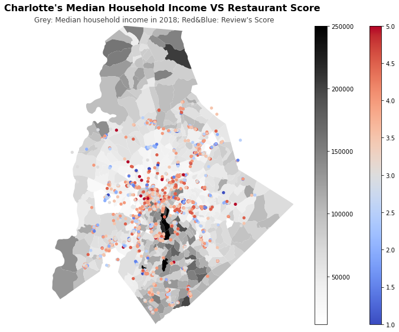

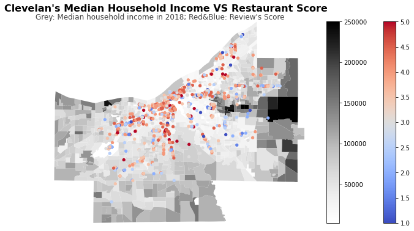

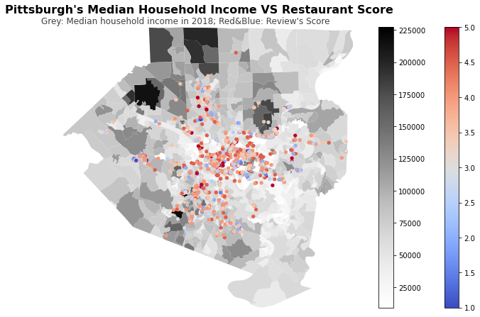

```python
for i in range(0, len(three_list)):
    fig, ax= plt.subplots(figsize=(10,10))
    # create a lined up colorbar axes
    divider = make_axes_locatable(ax)
    # legend for income
    cax = divider.append_axes("right", size="5%", pad=0.5, alpha =0.5)
    # leged for score
    cax1 = divider.append_axes("right", size="5%", pad=1)

    # plot the income
    three_list[i].plot(ax=ax,
                   cax = cax,
                   cmap = "Greys",
                   column='B19049_001E',
                   #alpha=0.7,
                   legend=True)


    # plot the colored score point
    three_list_resta_sf[i].plot(
        ax=ax,
        cax = cax1,
        column="stars",
        #categorical=True,
        cmap = "coolwarm",
        legend=True,
        alpha=1,
        markersize=18,
    )




    # Get the limits of the GeoDataFrame
    xmin, ymin, xmax, ymax = three_list[i].total_bounds

    # Set the xlims and ylims
    ax.set_xlim(xmin, xmax)
    ax.set_ylim(ymin, ymax)

    # Format
    plt.text(x=-120, y=5.2, s=title_list_resta[i], fontsize=16, weight='bold')
    plt.text(x=-110, y=5.05, s=subtitle, fontsize=12, alpha=0.75)

    ax.set_axis_off()
```

### 2.6 Comparing polarity vs. stars geographically

- Merge the restaurants GeoDataFrame with the DataFrame with the 'polarity' column for each review.
- Make a side-by-side plot with two columns: one subplot shows hex bins giving the polarity of the restaurant review and the other shows hex bins giving the number of stars

As we saw in Section 1, a strong correlation between the two subplots is observed

```python
pittsburgh_resta = three_list_resta_sf[2]
pittsburgh_resta = pittsburgh_resta.merge(pittsburgh_rw, left_on = "business_id", right_on ="business_id")

pittsburgh_resta = pittsburgh_resta.rename(columns={"stars_x": "Stars_for_Restaurant",
                                                    "stars_y": "Stars_from_each_customer"})
```

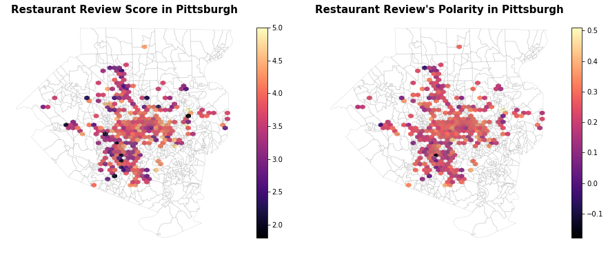

```python
import numpy as np
# Create the axes
fig, axes = plt.subplots(ncols=2, figsize=(15, 10))
ax1, ax2 = axes

#######create first map, hex of score of each review

xcoords = pittsburgh_resta.geometry.x
ycoords = pittsburgh_resta.geometry.y
hex_vals1 = ax1.hexbin(
    xcoords,
    ycoords,
    #mincnt = 1,
    C=pittsburgh_resta.Stars_from_each_customer,
    gridsize=40,
    cmap = 'magma'
)
# Add a colorbar and format for
cbar = fig.colorbar(hex_vals1, ax=ax1, fraction=0.04)


# Add the philly census geometry boundaries
three_list[2].plot(ax=ax1, facecolor="none", edgecolor="grey", linewidth=0.8, alpha=0.2)


ax1.set_axis_off()
ax1.set_aspect("equal")
ax1.set_title("Restaurant Review Score in Pittsburgh", weight="bold",fontsize=15)



#######create second map, hex of score of each polarity

# Use the .x and .y attributes
xcoords = pittsburgh_resta.geometry.x
ycoords = pittsburgh_resta.geometry.y
hex_vals2 = ax2.hexbin(
    xcoords,
    ycoords,
    C=pittsburgh_resta.polarity,
    gridsize=40,
    cmap = 'magma'
)

# Add a colorbar and format
cbar = fig.colorbar(hex_vals2, ax=ax2, fraction=0.04)

# Add the philly census geometry boundaries
three_list[2].plot(ax=ax2, facecolor="none", edgecolor="grey", linewidth=0.8, alpha=0.2)


ax2.set_axis_off()
ax2.set_aspect("equal")
ax2.set_title("Restaurant Review's Polarity in Pittsburgh", weight="bold",fontsize=15)
```